# BTS 510 Lab 12

```r
library(tidyverse)
set.seed(12345)
theme_set(theme_classic(base_size = 16))
```

## 1 Learning objectives

- *Describe* the logic of ANOVA
- *Conduct* and *interpret* the overall ANOVA test
- *Conduct* post hoc tests

## 2 Data

- `Amyloid` dataset (N = 57) in **Stat2Data** package
  - `Group`: mAD=Alzheimer’s, MCI=mild impairment, NCI=no impairment
  - `Abeta`: Amount of Abeta from the posterior cingulate cortex (pmol/g tissue)

```r
library(Stat2Data)
data(Amyloid)
head(Amyloid)
```

```
  Group Abeta
1   NCI   114
2   NCI    41
3   NCI   276
4   NCI     0
5   NCI    16
6   NCI   228
```

## 3 Descriptives and data visualization

### 3.1 Means, variances, and SDs by group

```r
Amyloid %>% group_by(Group) %>%
  summarize(mean = mean(Abeta),
            variance = var(Abeta),
            sd = sd(Abeta))
```

```
# A tibble: 3 × 4
  Group  mean variance    sd
  <fct> <dbl>    <dbl> <dbl>
1 mAD    761.  182068.  427.
2 MCI    341.  165168.  406.
3 NCI    336.  189756.  436.
```

- For some reason, these values get rounded to the whole number. You can get the full numbers to print if you use a package to print prettier tables, like **kableExtra** (only works for HTML output)

```r
library(kableExtra)
Amyloid %>% group_by(Group) %>%
  summarize(mean = mean(Abeta),
            variance = var(Abeta),
            sd = sd(Abeta)) %>%
  kable()
```

| Group | mean | variance | sd |
| --- | --- | --- | --- |
| mAD | 761.2941 | 182068.0 | 426.6942 |
| MCI | 341.0476 | 165168.4 | 406.4092 |
| NCI | 336.2632 | 189755.8 | 435.6096 |

### 3.2 Equal variance assumption

- Graphically

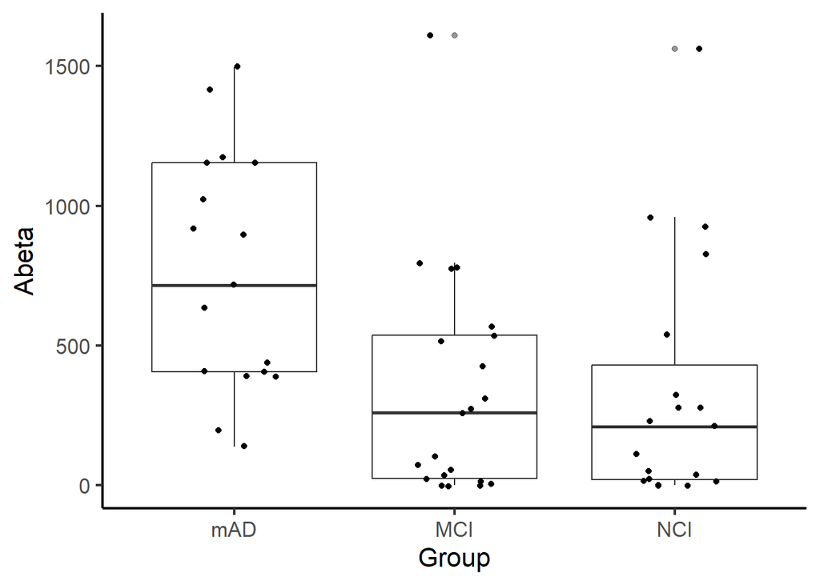

```r
ggplot(data = Amyloid,
       aes(x = Group, y = Abeta)) +
  geom_boxplot(alpha = 0.5) +
  geom_jitter(width = 0.2)
```

- Statistical test

```r
library(car)
leveneTest(Abeta ~ Group, data = Amyloid)
```

```
Levene's Test for Homogeneity of Variance (center = median)
      Df F value Pr(>F)
group  2  0.3505 0.7059
      54
```

- Variances are roughly equal – good to go!

## 4 Analysis of variance

- Use both `lm()` with `contr.sum` and `anova()` to get correct type III sums of squares

```r
m1 <- lm(Abeta ~ Group,
         contrasts=list(Group='contr.sum'),
         data = Amyloid)
anova(m1)
```

```
Analysis of Variance Table

Response: Abeta
          Df  Sum Sq Mean Sq F value   Pr(>F)
Group      2 2129969 1064985  5.9706 0.004544 **
Residuals 54 9632060  178371
---
Signif. codes:  0 '***' 0.001 '**' 0.01 '*' 0.05 '.' 0.1 ' ' 1
```

- Overall, there is an effect of `Group`
  - We reject the $H_0$ that all the group means are equal, F(2, 54) = 5.97, p <.01. At least one group mean is different from the others.

### 4.1 Normality assumption

- Graphically

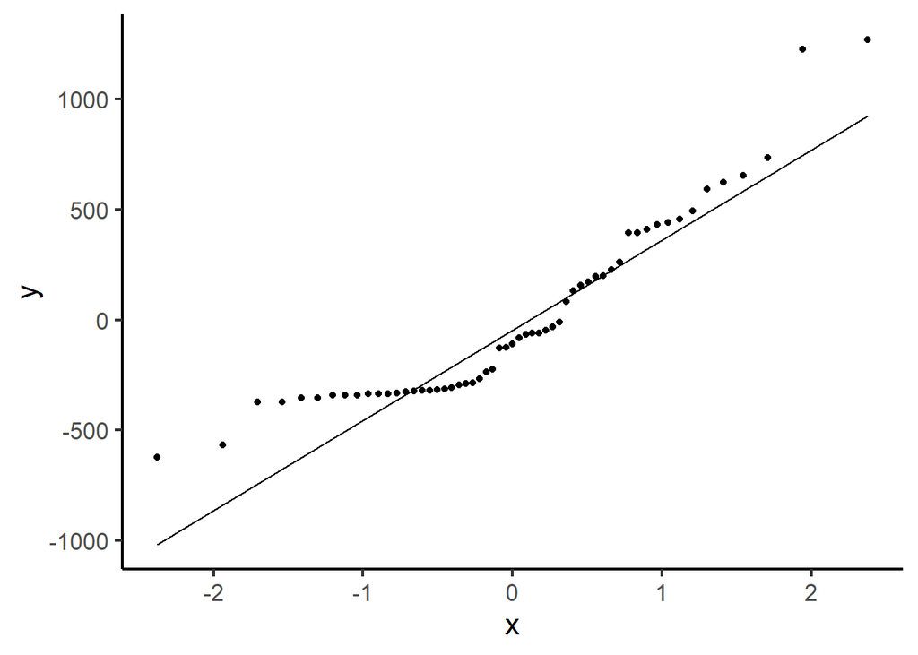

```r
m1resid <- data.frame(residuals(m1))
ggplot(data = m1resid,
       aes(sample = residuals.m1.)) +
  geom_qq() +
  geom_qq_line()
```

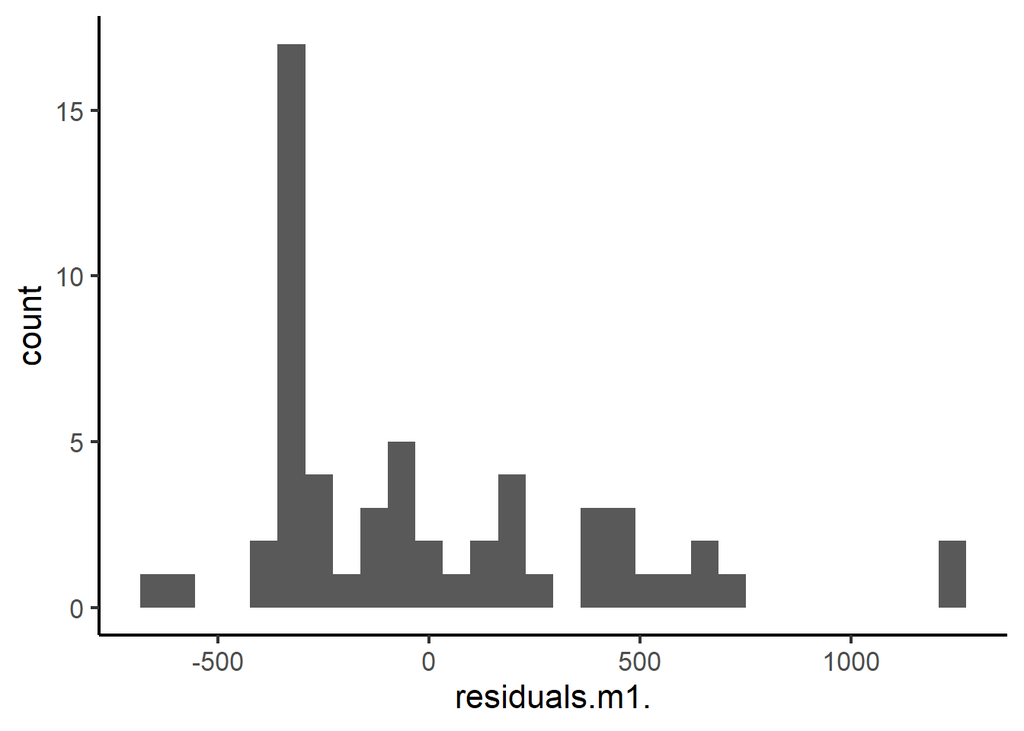

```r
m1resid <- data.frame(residuals(m1))
ggplot(data = m1resid,
       aes(x = residuals.m1.)) +
  geom_histogram()
```

- Statistical test

```r
shapiro.test(resid(m1))
```

```
    Shapiro-Wilk normality test

data:  resid(m1)
W = 0.88246, p-value = 4.857e-05
```

- Normality assumption is violated
  - We should consider non-parametric alternatives that don’t assume normality
  - But for the purposes of this class, we’re going to carry on anyway

## 5 Post hoc tests

- I’m only going to use the reference / dummy / `treatment` contrasts here
  - Feel free to try out the others
- Dummy coding compares each group to a specific reference group (e.g., control)
  - In R, the default reference group is the **first** group
  - Factors in R are ordered alphabetically (if character names) or numerically (if number names)
  - So this will do two comparisons (`mAD` is the reference group)
    - `mAD` vs `MCI`
    - `mAD` vs `NCI`

```r
m1_trt <- lm(Abeta ~ Group,
         contrasts=list(Group='contr.treatment'),
         data = Amyloid)
summary(m1_trt)
```

```
Call:
lm(formula = Abeta ~ Group, data = Amyloid, contrasts = list(Group = "contr.treatment"))

Residuals:
   Min     1Q Median     3Q    Max
-623.3 -322.3 -108.3  227.9 1269.0

Coefficients:
            Estimate Std. Error t value Pr(>|t|)
(Intercept)    761.3      102.4   7.432 8.19e-10 ***
GroupMCI      -420.2      137.8  -3.050  0.00354 **
GroupNCI      -425.0      141.0  -3.014  0.00392 **
---
Signif. codes:  0 '***' 0.001 '**' 0.01 '*' 0.05 '.' 0.1 ' ' 1

Residual standard error: 422.3 on 54 degrees of freedom
Multiple R-squared:  0.1811,    Adjusted R-squared:  0.1508
F-statistic: 5.971 on 2 and 54 DF,  p-value: 0.004544
```

### 5.1 Multiple comparisons

- If we controlled for multiple comparisons what are our conclusions?
  - Do those differ from the conclusions where we didn’t control for multiple comparisons?

```r
p.adjust(c(0.00354, 0.00392), "holm", 2)
```

```
[1] 0.00708 0.00708
```

```r
p.adjust(c(0.00354, 0.00392), "BH", 2)
```

```
[1] 0.00392 0.00392
```

## 6 Conclusions

In plain language:

1. Are there differences in amyloid beta levels for the different impairment groups?
2. Which groups are different from one another?